# Lab #7: Modeling with Statistics

Data Science and Society (Sociology 367)

**Lab #7 Markdown File**

**[Lab Instructions](https://dssoc.github.io/assignments/lab_instructions.html)**

In this lab, we will practice making and visualizing statistical models of data using R.

See the “Instructions” section of the [Introduction to Lab Assignments](https://dssoc.github.io/assignments/lab_instructions.html) page for more information about the labs. That page also gives descriptions for the datasets we will be using.

**Required reading:**

- R for Data Science: [Modeling (Chapters 23-25)](https://r4ds.had.co.nz/model-intro.html)
- [Quick Guide: Interpreting Simple Linear Model Output in R](https://feliperego.github.io/blog/2015/10/23/Interpreting-Model-Output-In-R)

**Optional reading:**

- [Simple Linear Regression - An example using R](https://feliperego.github.io/blog/2015/03/11/Simple-Linear-Regression-Example-in-R)

## Example Questions

**ex1. Make a box plot showing the average approximate age of congress members by gender.**

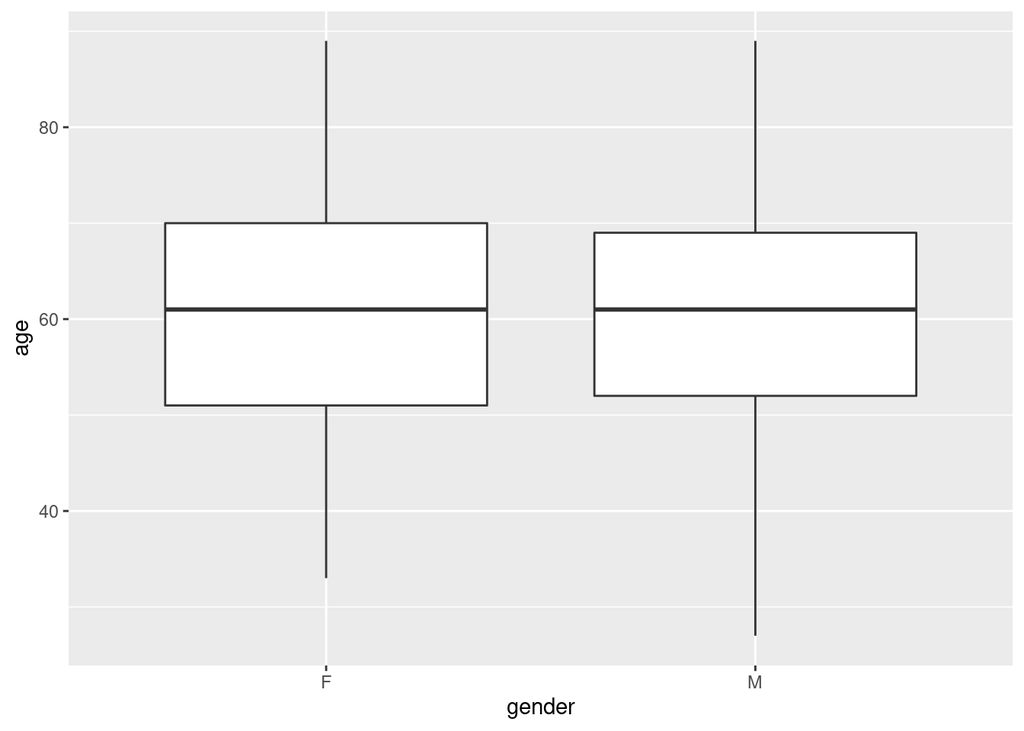

```r
# Your answer here
congress %>%
  mutate(age=2022-birthyear) %>%
  #group_by(gender) %>%
  #summarize(av_age=mean(age)) %>%
  ggplot(aes(x=gender, y=age)) +
    geom_boxplot()
```

**ex2. Create a scatter plot showing the relationship between age and number of social media accounts that congress members have, and add a linear trendline.**

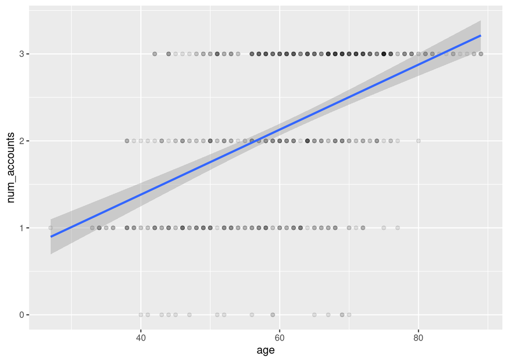

```r
# Your answer here
congress %>%
  mutate(age=2022-birthyear) %>%
  left_join(congress_contact, by='bioguide_id') %>%
  mutate(num_accounts = (twitter!='') + (facebook!='') + (youtube!='')) %>%
  ggplot(aes(x=age, y=num_accounts)) +
    geom_point(alpha=0.1) +
    geom_smooth(method='lm', formula= y ~ x)
```

**ex3. Create a linear regression model predicting the number of social media accounts a congress member has from the following variables: type (senator or representative), age, party, and gender. Controlling for other factors, how would you communicate the relationship between age and the number of social media accounts a congress member has?**

```r
# create dataframe from which we will train the model
model_df <- congress %>%
  mutate(age=2022-birthyear, is_repub=party=='Republican') %>%
  left_join(congress_contact, by='bioguide_id') %>%
  mutate(num_accounts = (twitter!='') + (facebook!='') + (youtube!=''))

# fit the full model with all the variables
m <- lm(num_accounts ~ type + age + is_repub + gender, data=model_df)
m %>% summary()
```

```
##
## Call:
## lm(formula = num_accounts ~ type + age + is_repub + gender, data = model_df)
##
## Residuals:
##     Min      1Q  Median      3Q     Max
## -2.8774 -0.5236  0.1205  0.6146  1.8324
##
## Coefficients:
##               Estimate Std. Error t value Pr(>|t|)
## (Intercept)  -0.149337   0.186545  -0.801  0.42375
## typesen       0.242193   0.087756   2.760  0.00598 **
## age           0.034899   0.002873  12.149  < 2e-16 ***
## is_repubTRUE -0.218618   0.069963  -3.125  0.00188 **
## genderM       0.341592   0.078062   4.376 1.46e-05 ***
## ---
## Signif. codes:  0 '***' 0.001 '**' 0.01 '*' 0.05 '.' 0.1 ' ' 1
##
## Residual standard error: 0.7773 on 534 degrees of freedom
## Multiple R-squared:  0.2812, Adjusted R-squared:  0.2758
## F-statistic: 52.22 on 4 and 534 DF,  p-value: < 2.2e-16
```

```
Response: On average, congress members have approximately 0.034 more social media accounts for every one year older they are.
```

**ex4. Using the model from the previous question, generate the predicted number of social media accounts that a Republican female senator born in 1952 would have. How does this compare with the actual congress members that match that profile?**

```r
# generate a dummy dataframe for prediction
example_df <- data.frame(gender=c('F'), is_repub=T, type=c('sen'), age=c(2022-1952))
m %>% predict(example_df)
```

```
##        1
## 2.317202
```

```r
# show actual congress members
model_df %>%
  filter(gender=='F', party=='Republican', type=='sen', birthyear==1952) %>%
  select(full_name, num_accounts)
```

```
##          full_name num_accounts
## 1 Susan M. Collins            3
## 2 Marsha Blackburn            3
```

```
The model predicts that congress members with this profile would have an average of 2.3 social media accounts, but both congress members have 3 accounts.
```

**ex5. Create three statistical models to predict the number of social media accounts that congress members have: one with gender only, one with political party (you may create a dummy variable for Republicans or Democrats) only, and one that includes both gender and political party. What can you learn from the combination of these three models?**

```r
lm(num_accounts ~ gender, data=model_df) %>% summary()
```

```
##
## Call:
## lm(formula = num_accounts ~ gender, data = model_df)
##
## Residuals:
##      Min       1Q   Median       3Q      Max
## -2.22704 -0.94558  0.05442  0.77296  1.05442
##
## Coefficients:
##             Estimate Std. Error t value Pr(>|t|)
## (Intercept)  1.94558    0.07469  26.049  < 2e-16 ***
## genderM      0.28146    0.08758   3.214  0.00139 **
## ---
## Signif. codes:  0 '***' 0.001 '**' 0.01 '*' 0.05 '.' 0.1 ' ' 1
##
## Residual standard error: 0.9056 on 537 degrees of freedom
## Multiple R-squared:  0.01887,    Adjusted R-squared:  0.01704
## F-statistic: 10.33 on 1 and 537 DF,  p-value: 0.001389
```

```r
lm(num_accounts ~ is_repub, data=model_df) %>% summary()
```

```
##
## Call:
## lm(formula = num_accounts ~ is_repub, data = model_df)
##
## Residuals:
##      Min       1Q   Median       3Q      Max
## -2.26182 -1.03409 -0.03409  0.73818  0.96591
##
## Coefficients:
##              Estimate Std. Error t value Pr(>|t|)
## (Intercept)   2.26182    0.05470  41.350  < 2e-16 ***
## is_repubTRUE -0.22773    0.07816  -2.914  0.00372 **
## ---
## Signif. codes:  0 '***' 0.001 '**' 0.01 '*' 0.05 '.' 0.1 ' ' 1
##
## Residual standard error: 0.9071 on 537 degrees of freedom
## Multiple R-squared:  0.01556,    Adjusted R-squared:  0.01373
## F-statistic:  8.49 on 1 and 537 DF,  p-value: 0.003721
```

```r
lm(num_accounts ~ gender + is_repub, data=model_df) %>% summary()
```

```
##
## Call:
## lm(formula = num_accounts ~ gender + is_repub, data = model_df)
##
## Residuals:
##      Min       1Q   Median       3Q      Max
## -2.40827 -1.03188 -0.03188  0.90888  1.28527
##
## Coefficients:
##              Estimate Std. Error t value Pr(>|t|)
## (Intercept)   2.03188    0.07682  26.450  < 2e-16 ***
## genderM       0.37639    0.08965   4.199 3.14e-05 ***
## is_repubTRUE -0.31715    0.07987  -3.971 8.14e-05 ***
## ---
## Signif. codes:  0 '***' 0.001 '**' 0.01 '*' 0.05 '.' 0.1 ' ' 1
##
## Residual standard error: 0.8934 on 536 degrees of freedom
## Multiple R-squared:  0.04691,    Adjusted R-squared:  0.04335
## F-statistic: 13.19 on 2 and 536 DF,  p-value: 2.559e-06
```

[output not shown]

```r
# Your answer here
table(model_df %>% select(gender, is_repub))
```

```
##       is_repub
## gender FALSE TRUE
##      F   107   40
##      M   168  224
```

```r
cor.test(as.numeric(model_df$gender=='M'), as.numeric(model_df$is_repub))
```

```
##
##  Pearson's product-moment correlation
##
## data:  as.numeric(model_df$gender == "M") and as.numeric(model_df$is_repub)
## t = 6.4117, df = 537, p-value = 3.156e-10
## alternative hypothesis: true correlation is not equal to 0
## 95 percent confidence interval:
##  0.1864090 0.3433889
## sample estimates:
##       cor
## 0.2666667
```

```r
#cor.test(gender + is_repub, data=model_df)
```